# R-Packages for time series data

# Quantmod

Contiution to financial hw3 problem, **quantmod** package offers Quantitative Financial Modelling & Trading Framework for R. This page discusses some of the ways quantmod package can be used in plotting financial charts.

Quantmod package can be used for exracting and plotting equities, economic indicators, FX, commodities and cryptocurrencies (the latest financial assetclass)

```r
library(quantmod)
getSymbols("AMZN", src ="yahoo") #Equities: getting data for Amazon from yahoo finance
```

```
## [1] "AMZN"
```

```r
getSymbols("AAPL", src ="yahoo")
```

```
## [1] "AAPL"
```

```r
getSymbols("CPIAUCSL",src="FRED") #Economic indicators: getting data for "Consumer Price Index for All Urban Consumers: All Items" from Federal Reserve Bank of St. Louis FRED®
```

```
## [1] "CPIAUCSL"
```

```r
getSymbols("EUR/USD",src="oanda") #FX rates: getting EUR USD rate from Oanda corp
```

```
## [1] "EURUSD"
```

```r
getSymbols("XAU/USD",src="oanda") #Commodities:  getting Gold price in USD from Oanda corp
```

```
## [1] "XAUUSD"
```

```r
getSymbols('BTCUSD=X',src = "yahoo") #Cryptocurrency: getting Bitcoin price in USD
```

```
## [1] "BTCUSD=X"
```

- A simple *barChart* command in qunatmod plots historical movements in stockprices.
- Quantmod can be used to plot Bollinger bands. They are plotted 2 standard deviations above and below the simple moving average
- This package also plots Moving Average conversion divergence line, which helps trades to decide their entry and exit points.

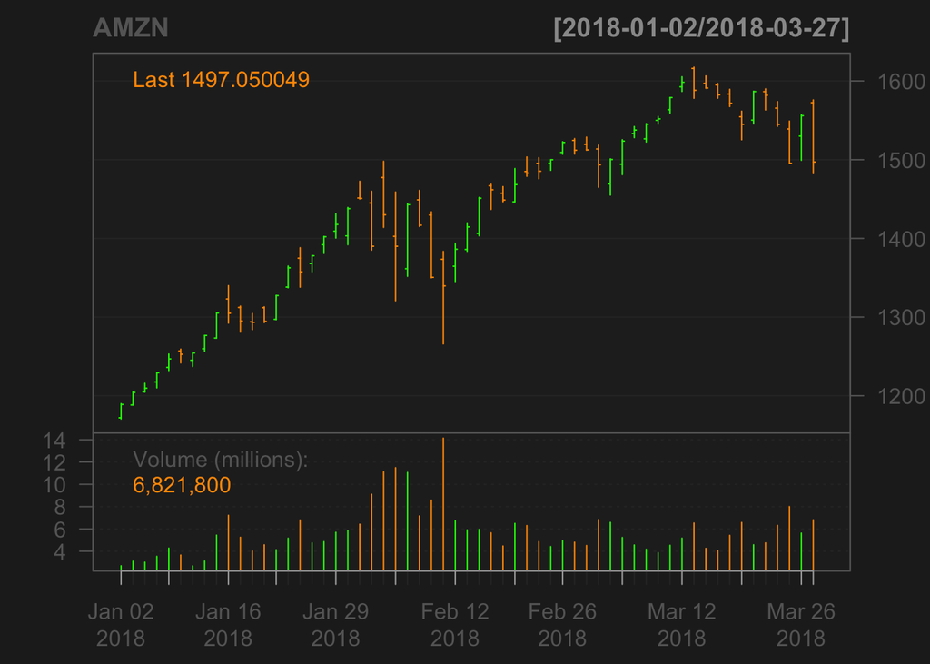

```r
barChart(AMZN, subset='last 3 months')  #This command shows how Amazon stock has been performing over last 3 months
```

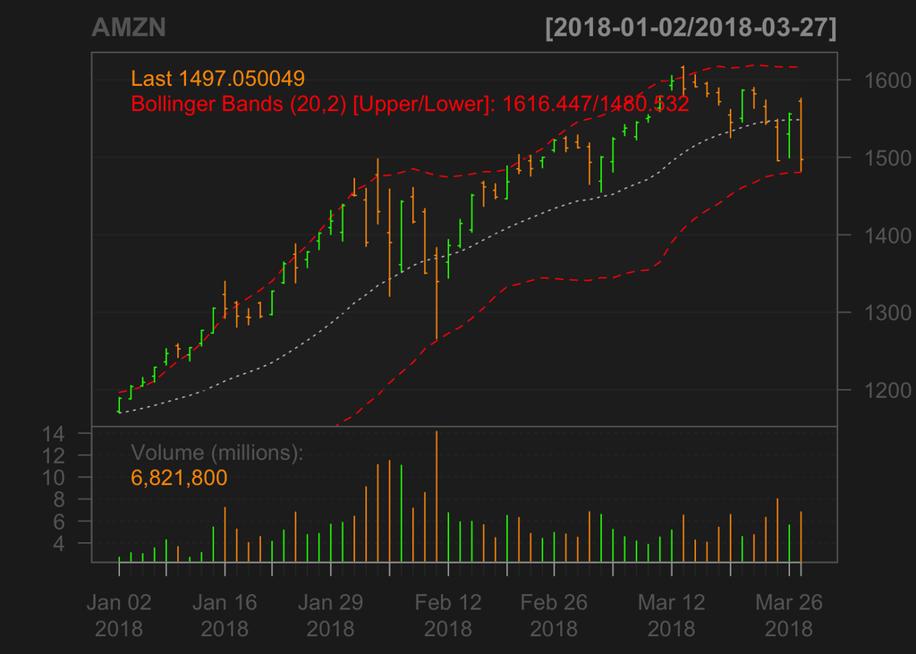

```r
addBBands()  # this adds Bollinger bands to stock price movement.
```

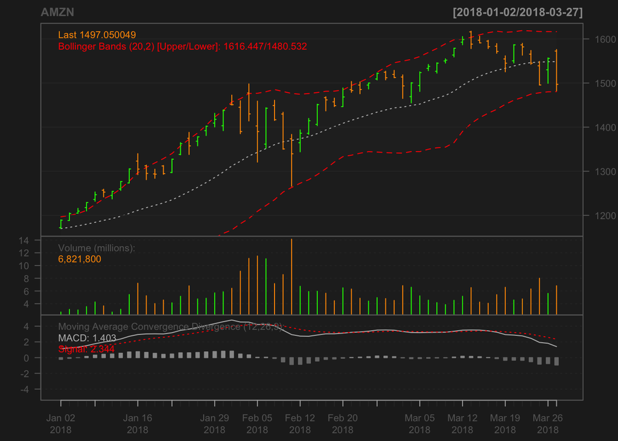

```r
addMACD() #this plots MACD
```

To change background of the plot to white, theme paramenter can be introduced in below fashion.

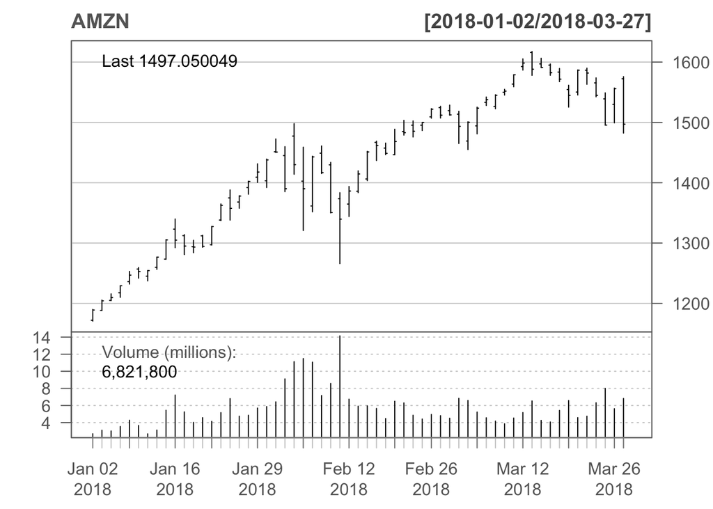

```r
barChart(AMZN, subset='last 3 months',theme='white.mono')
```

Another important type of plot to analyze historical financial data is candlestick chart. Quantmod can be used to plot candlestick plot in a single line command.

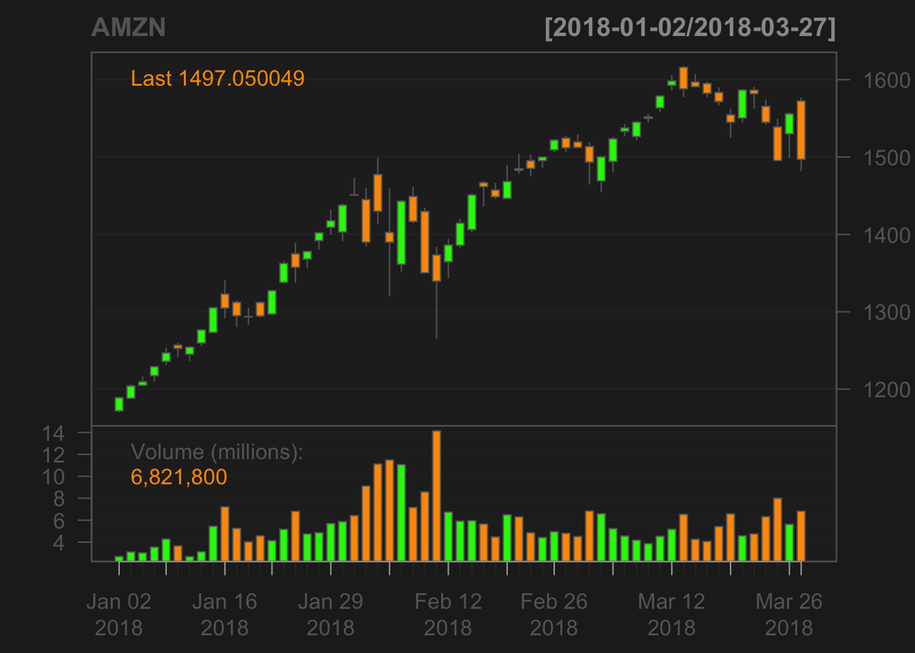

```r
candleChart(AMZN,subset='last 3 months') #here green indicates upward moving stock price
```

```r
#orange indicates downward moving stock price
```

Color coding for price movements and plot theme in candlechart can be changed with in the same line.

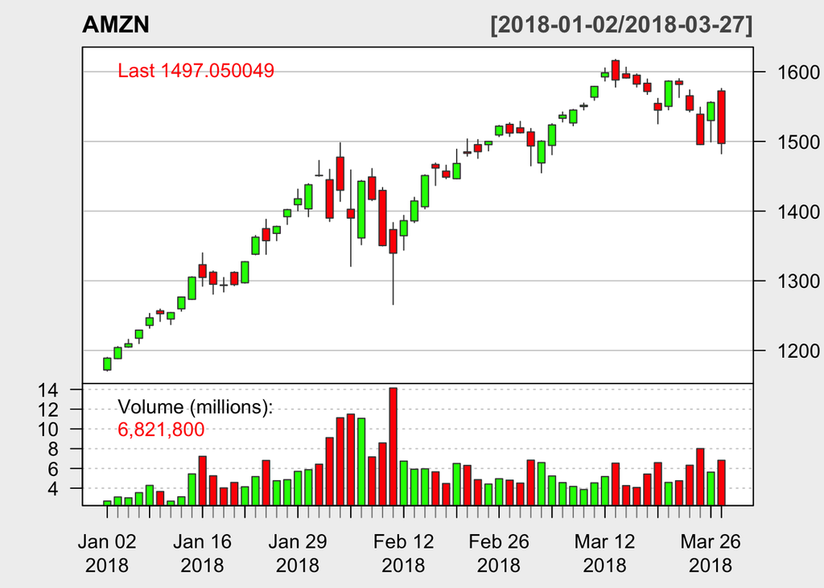

```r
candleChart(AMZN,subset='last 3 months',up.col='green',dn.col='red', theme='white')
```

Using this package, we can adjust the duration of candlestick. For eg: the below code plots weekly candlestick chart of Amazon stock price movement.

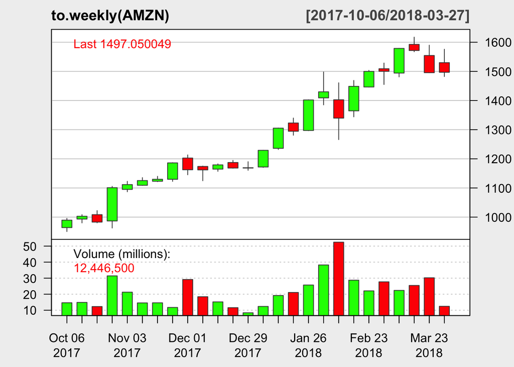

```r
candleChart(to.weekly(AMZN),subset='last 6 months',up.col='green',dn.col='red', theme='white')
```

Sometime just looking at plain vanilla line chart would be sufficient to explain / understand price movements. For this scenario, following command can be used.

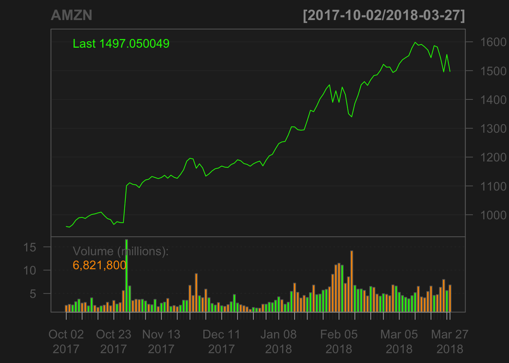

```r
lineChart(AMZN, subset='last 6 months')
```

# dygraphs for R

As stock prices are time-series data, sometimes it is necessary to know the stock prices of 2 or more different stocks on a single chart. For this, the package called **dygraph** can be used. This package is a R interface to the dygraph JavaScript charting library.

One cool feature of this multi line chart plotted with this package is interactiveness unlike static charts from **ggplot2**. If you hover your mouse, each series individual values are displayed.

```r
library(dygraphs)
stockprices <- cbind(AMZN$AMZN.Adjusted, AAPL$AAPL.Adjusted)
dygraph(stockprices)
```

[interactive chart not shown]

*dygraph* package provides another feature for dynamically selecting the range of the chart we need to see. If we use indexed data, this helps in understanding returns of 2 different stocks or asset classes. Bottom of the chart has slider which acts as a range selector.

```r
dygraph(stockprices) %>% dyRangeSelector()
```

[interactive chart not shown]

## References:

1. https://www.quantmod.com/
2. https://rstudio.github.io/dygraphs/index.html